# Myopic Loss Aversion in Investment Behavior - Analysis

Dean K. Young

January 21, 2016

Please refer to thesis document for commentary.

### Initial data setup

Type: 1 = Monthly, 2 = Yearly, 3 = Inflated Monthly  
Choices are for Bond allocation (note that the simulator produces choices as for Stock allocation)

### Figure 1

## Page 16

Distribution of final allocation choices for each condition

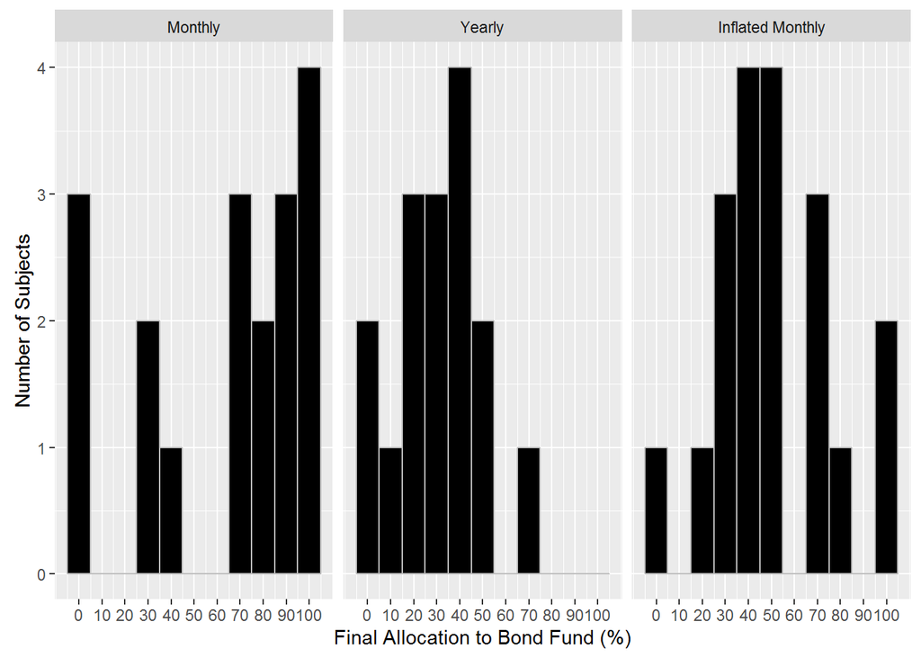

```r
hist.data <- wide.data %>% select(Type,Final.Choice) %>% mutate(Final.Choice = Final.Choice * 100) %>%
  mutate(Type = ifelse(Type == 1, "Monthly", ifelse(Type == 2, "Yearly","Inflated Monthly")))

hist.data$Type <- factor(hist.data$Type, levels = c("Monthly", "Yearly", "Inflated Monthly"))

ggplot(hist.data, aes(Final.Choice)) + geom_histogram(binwidth=10, fill="black",color="gray") +
  facet_wrap(~ Type) +
  scale_x_continuous(breaks=seq(0,100,10)) +
  xlab("Final Allocation to Bond Fund (%)") +
  ylab("Number of Subjects")
```

### Table 1

## Page 17

Percent of portfolio allocated to the Bond Fund for final choice

```r
ste <- function(x) sqrt(var(x,na.rm=TRUE)/sum(!is.na(x))) #standard error computation

summ.final <- wide.data %>% group_by(Type) %>%
  summarise(Avg = mean(Final.Choice), sd = sd(Final.Choice), ste = ste(Final.Choice))

t.test1 <- wide.data %>% filter(Type == 1 | Type == 2)
t.test2 <- wide.data %>% filter(Type == 1 | Type == 3)
t.test3 <- wide.data %>% filter(Type == 2 | Type == 3)

t.test(Final.Choice~Type,t.test1)
```

```
##
##  Welch Two Sample t-test
##
## data:  Final.Choice by Type
## t = 3.3173, df = 25.913, p-value = 0.002698
## alternative hypothesis: true difference in means is not equal to 0
## 95 percent confidence interval:
##  0.1243737 0.5297930
## sample estimates:
## mean in group 1 mean in group 2
##       0.6333333       0.3062500
```

```r
t.test(Final.Choice~Type,t.test2)
```

```
##
##  Welch Two Sample t-test
##
## data:  Final.Choice by Type
## t = 1.2182, df = 30.404, p-value = 0.2325
## alternative hypothesis: true difference in means is not equal to 0
## 95 percent confidence interval:
##  -0.08651922  0.34265957
## sample estimates:
## mean in group 1 mean in group 3
##       0.6333333       0.5052632
```

```r
t.test(Final.Choice~Type,t.test3)
```

```
##
##  Welch Two Sample t-test
##
## data:  Final.Choice by Type
## t = -2.6263, df = 32.353, p-value = 0.01308
## alternative hypothesis: true difference in means is not equal to 0
## 95 percent confidence interval:
##  -0.35330050 -0.04472582
## sample estimates:
## mean in group 2 mean in group 3
##       0.3062500       0.5052632
```

### Table 2A-B

## Page 17

Percent of portfolio allocated to the Bond Fund for final 40 periods

```r
summ.40 <- long.data.40 %>% group_by(Type) %>%
  summarise(Avg = mean(Choice,na.rm=TRUE), sd = sd(Choice,na.rm=TRUE), ste = ste(Choice))

t.2.test1 <- long.data.40 %>% filter(Type == 1 | Type == 2)
t.2.test2 <- long.data.40 %>% filter(Type == 1 | Type == 3)
t.2.test3 <- long.data.40 %>% filter(Type == 2 | Type == 3)

t.test.cluster(t.2.test1$Choice,t.2.test1$ID,t.2.test1$Type)
```

```
##                                     1            2
## N                                   720           64
## Clusters                            18           16
## Mean                                0.5756944    0.3000000
## SS among clusters within groups     53.6904       1.0000
## SS within clusters within groups    42.15425      1.38000
## MS among clusters within groups     1.709075
## d.f.                                32
## MS within clusters within groups    0.05804567
## d.f.                                750
## Na                                  22.42424
## Intracluster correlation            0.5591669
## Variance Correction Factor          22.807508     2.677501
## Variance of effect                  0.004267114
## Variance without cluster adjustment 0.0009875825
## Design Effect                       4.320767
## Effect (Difference in Means)        -0.2756944
## S.E. of Effect                      0.06532315
## 0.95 Confidence limits              -0.4037255   -0.1476634
## Z Statistic                         -4.220471
## 2-sided P Value                     2.437925e-05
```

```r
t.test.cluster(t.2.test2$Choice,t.2.test2$ID,t.2.test2$Type)
```

```
##                                     1            3
## N                                   720          760
## Clusters                            18           19
## Mean                                0.5756944    0.4151316
## SS among clusters within groups     53.69040     12.27974
## SS within clusters within groups    42.15425     42.31625
## MS among clusters within groups     1.884861
## d.f.                                35
## MS within clusters within groups    0.05853812
## d.f.                                1443
## Na                                  38.88889
## Intracluster correlation            0.4451401
## Variance Correction Factor          18.36046     18.36046
## Variance of effect                  0.002906953
## Variance without cluster adjustment 0.0001583268
## Design Effect                       18.36046
## Effect (Difference in Means)        -0.1605629
## S.E. of Effect                      0.05391616
## 0.95 Confidence limits              -0.26623661  -0.05488912
## Z Statistic                         -2.97801
## 2-sided P Value                     0.002901267
```

```r
t.test.cluster(t.2.test3$Choice,t.2.test3$ID,t.2.test3$Type)
```

```
##                                     2            3
## N                                    64          760
## Clusters                            16           19
## Mean                                0.3000000    0.4151316
## SS among clusters within groups      1.00000     12.27974
## SS within clusters within groups     1.38000     42.31625
## MS among clusters within groups     0.4024163
## d.f.                                33
## MS within clusters within groups    0.05538181
## d.f.                                789
## Na                                  22.94118
## Intracluster correlation            0.2145422
## Variance Correction Factor          1.643626     9.367144
## Variance of effect                  0.002104888
## Variance without cluster adjustment 0.0009382116
## Design Effect                       2.243511
## Effect (Difference in Means)        0.1151316
## S.E. of Effect                      0.04587906
## 0.95 Confidence limits              0.02521027   0.20505289
## Z Statistic                         2.509458
## 2-sided P Value                     0.01209166
```

## Page 16-17

Controlling for survey results

```r
ctrl.t.test1 <- t.test1 %>% mutate(type.dummy = ifelse(Type==1,0,1), Final.Choice = Final.Choice*100)
ctrl.t.test2 <- t.test2 %>% mutate(type.dummy = ifelse(Type==1,0,1), Final.Choice = Final.Choice*100)
ctrl.t.test3 <- t.test3 %>% mutate(type.dummy = ifelse(Type==2,0,1), Final.Choice = Final.Choice*100)

# Using HC-robust standard errors
coeftest(lm(Final.Choice~type.dummy+Q3+Q4+Q5,ctrl.t.test1), vcov=vcovHC)
```

```
##
## t test of coefficients:
##
##              Estimate Std. Error t value  Pr(>|t|)
## (Intercept)  64.73631    8.25396  7.8431 1.194e-08 ***
## type.dummy  -36.12193   11.65823 -3.0984  0.004295 **
## Q3           22.45885   15.41897  1.4566  0.155977
## Q4          -41.33860   29.04523 -1.4232  0.165334
## Q5            0.63823   18.03335  0.0354  0.972010
## ---
## Signif. codes:  0 '***' 0.001 '**' 0.01 '*' 0.05 '.' 0.1 ' ' 1
```

```r
coeftest(lm(Final.Choice~type.dummy+Q3+Q4+Q5,ctrl.t.test2), vcov=vcovHC)
```

```
##
## t test of coefficients:
##
##             Estimate Std. Error t value  Pr(>|t|)
## (Intercept)  71.8069     8.3034  8.6479 6.985e-10 ***
## type.dummy  -19.8067    10.6161 -1.8657   0.07127 .
## Q3           -4.5815    13.0984 -0.3498   0.72880
## Q4          -68.4969    10.6637 -6.4234 3.205e-07 ***
## Q5           -2.0385     9.1262 -0.2234   0.82467
## ---
## Signif. codes:  0 '***' 0.001 '**' 0.01 '*' 0.05 '.' 0.1 ' ' 1
```

```r
coeftest(lm(Final.Choice~type.dummy+Q3+Q4+Q5,ctrl.t.test3), vcov=vcovHC)
```

```
##
## t test of coefficients:
##
##             Estimate Std. Error t value  Pr(>|t|)
## (Intercept)  30.2062     5.6795  5.3185 9.476e-06 ***
## type.dummy   21.7384     8.6009  2.5275   0.01699 *
## Q3           -3.1497    10.6413 -0.2960   0.76928
## Q4           20.1831    12.4110  1.6262   0.11436
## Q5           -4.4792     9.5083 -0.4711   0.64099
## ---
## Signif. codes:  0 '***' 0.001 '**' 0.01 '*' 0.05 '.' 0.1 ' ' 1
```

### Figure 2A-B

## Page 18-19

Bootstrapped differences in average allocation to the Bond Fund for the monthly and yearly conditions (monthly and inflated-monthly - B)

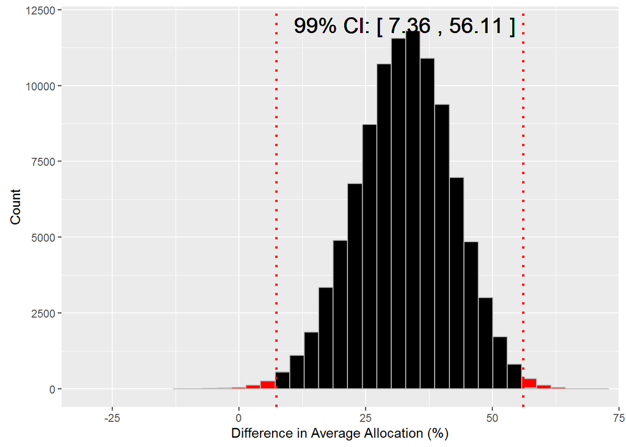

```r
bootstrap <- function(a,b){
  set.seed(76)
  boot.samples <- c(rep(NA,100000))
  for (i in 1:100000){
    t.1 <- sample(length(a), length(a), replace=TRUE)
    t.2 <- sample(length(b), length(b), replace=TRUE)
    t <- mean(a[t.1])-mean(b[t.2])
    boot.samples[i] <- t

  }
  return(as.data.frame(boot.samples) %>% rename(x=boot.samples))
}

boot.samples.1 <- bootstrap(monthly$Final.Choice,yearly$Final.Choice)
boot.samples.2 <- bootstrap(monthly$Final.Choice,infmonthly$Final.Choice)

CI.1 <- quantile(boot.samples.1$x,c(.005,.995))
CI.2 <- quantile(boot.samples.2$x,c(.005,.995))

boot.samples.1 %<>% mutate(CI = x < CI.1[1] | x > CI.1[2])
boot.samples.2 %<>% mutate(CI = x < CI.2[1] | x > CI.2[2])

ggplot(aes(x, fill=CI), data=boot.samples.1) + geom_histogram(color="gray") +
  geom_vline(xintercept=CI.1, linetype="dotted", color="red", size= 1) +
  geom_text(label=paste("99% CI: [",round(CI.1[1],2),",",round(CI.1[2],2),"]"), aes(x=mean(boot.samples.1$x),y=12000), size=6) +
  scale_fill_manual(values = c("black", "red")) +
  guides(fill=FALSE) +
  coord_cartesian(xlim=c(-30,70), ylim=c(0,12000)) +
  xlab("Difference in Average Allocation (%)") +
  ylab("Count")
```

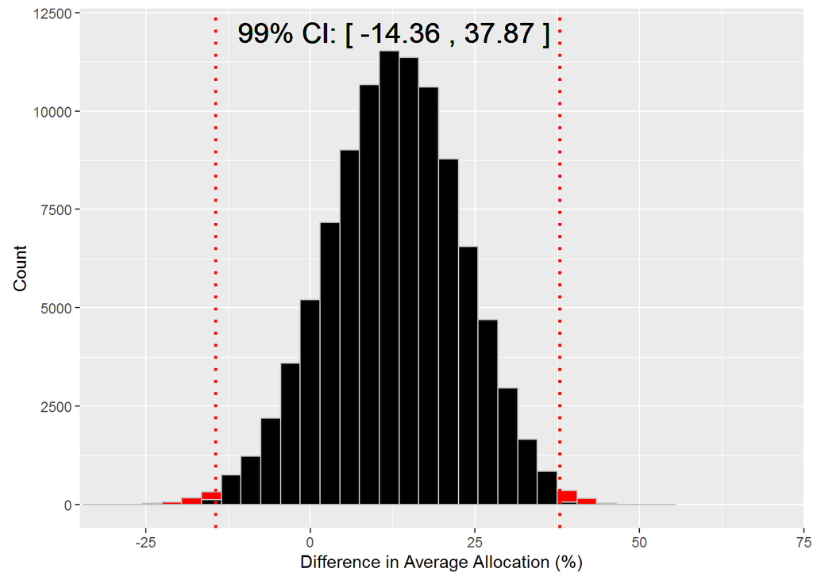

```r
ggplot(aes(x, fill=CI), data=boot.samples.2) + geom_histogram(color="gray") +
  geom_vline(xintercept=CI.2, linetype="dotted", color="red", size= 1) +
  geom_text(label=paste("99% CI: [",round(CI.2[1],2),",",round(CI.2[2],2),"]"), aes(x=mean(boot.samples.2$x),y=12000), size=6) +
  scale_fill_manual(values = c("black", "red"), name="") +
  guides(fill=FALSE) +
  coord_cartesian(xlim=c(-30,70), ylim=c(0,12000)) +
  xlab("Difference in Average Allocation (%)") +
  ylab("Count")
```

### Figure 3A-C

## Page 21-22

Monthly (Yearly) (Inflated-Monthly) condition subjects’ autocorrelation functions (ACF) of allocation choices

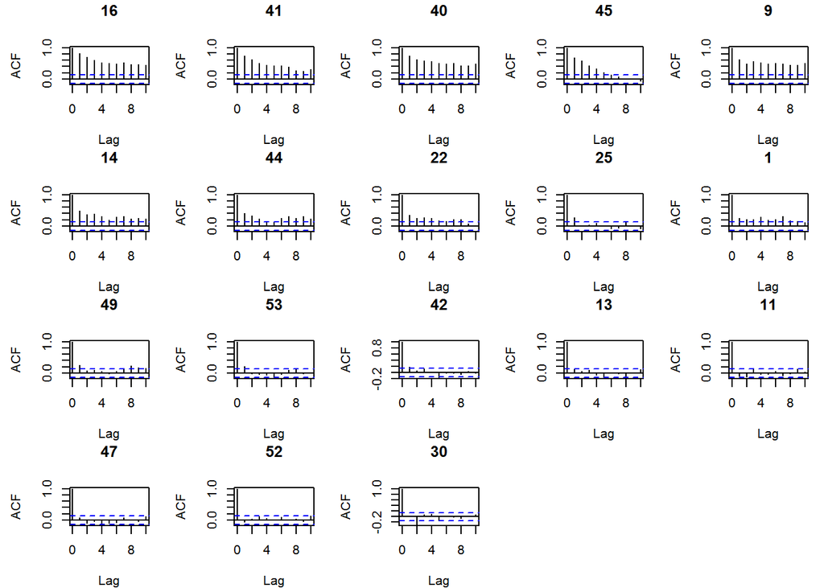

```r
monthly.data.lm <- monthly %>% select(ID,num_range("X",1:200)) %>%
  gather("Period","Choice",2:201) %>% mutate(Period=as.numeric(substring(Period,2)), Choice=Choice*100)

yearly.data.lm <- yearly %>% select(ID,num_range("X",1:200)) %>%
  gather("Period","Choice",2:201) %>% mutate(Period=as.numeric(substring(Period,2))) %>%
  filter(is.na(Choice)==FALSE) %>% mutate(Period = (Period %/% 10) + 1, Choice=Choice*100)

infmonthly.data.lm <- infmonthly %>% select(ID,num_range("X",1:200)) %>%
  gather("Period","Choice",2:201) %>% mutate(Period=as.numeric(substring(Period,2)), Choice=Choice*100)

ts.monthly <- monthly.data.lm %>% spread(ID,Choice) %>% select(-Period)
ts.yearly <- yearly.data.lm %>% spread(ID,Choice) %>% select(-Period)
ts.infmonthly <- infmonthly.data.lm %>% spread(ID,Choice) %>% select(-Period)

### Code to sort ACFs from highest (absolute) ACF for lag 1 to lowest ACF for lag 1
acf.rank <- as.matrix(t(c(NA,NA,NA)),nrow=1,ncol=3) %>% as.data.frame() %>%
  rename(ID=V1,ACF_1=V2,Type=V3)

for (x in colnames(ts.monthly)){
  a <- c(x,acf(ts.monthly[[x]],plot=FALSE)$acf[2],1) %>% t() %>% as.data.frame() %>%
    rename(ID=V1,ACF_1=V2,Type=V3)
  acf.rank %<>% bind_rows(a)

}
for (x in colnames(ts.yearly)){
  a <- c(x,acf(ts.yearly[[x]],plot=FALSE)$acf[2],2) %>% t() %>% as.data.frame() %>%
    rename(ID=V1,ACF_1=V2,Type=V3)
  acf.rank %<>% bind_rows(a)

}
for (x in colnames(ts.infmonthly)){
  a <- c(x,acf(ts.infmonthly[[x]],plot=FALSE)$acf[2],3) %>% t() %>% as.data.frame() %>%
    rename(ID=V1,ACF_1=V2,Type=V3)
  acf.rank %<>% bind_rows(a)

}

acf.rank %<>% slice(2:n()) %>% mutate(ACF_1 = abs(as.numeric(ACF_1)))

acf.rank.1 <- acf.rank %>% filter(Type==1) %>% arrange(desc(ACF_1))
acf.rank.2 <- acf.rank %>% filter(Type==2) %>% arrange(desc(ACF_1))
acf.rank.3 <- acf.rank %>% filter(Type==3) %>% arrange(desc(ACF_1))
### End sorting code

par(mar=c(4,4.5,3,1))
par(mfrow=c(4,5))

for (x in acf.rank.1$ID) {
  acf(ts.monthly[[x]],lag.max=10, plot=FALSE) %>% plot(main = x)

}

par(mfrow=c(4,5))
```

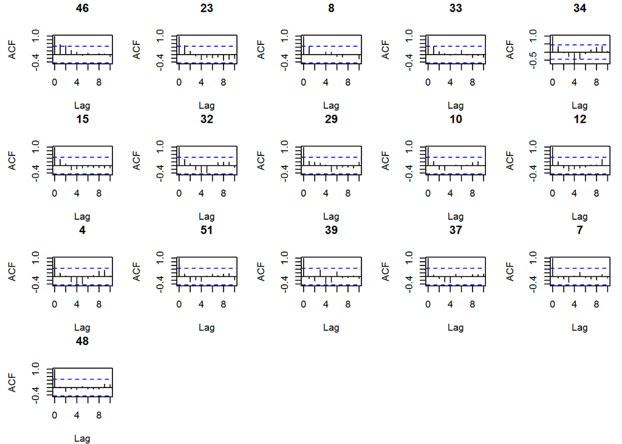

```r
for (x in acf.rank.2$ID){
  acf(ts.yearly[[x]],lag.max=10, plot=FALSE) %>% plot(main = x)

}

par(mfrow=c(4,5))
```

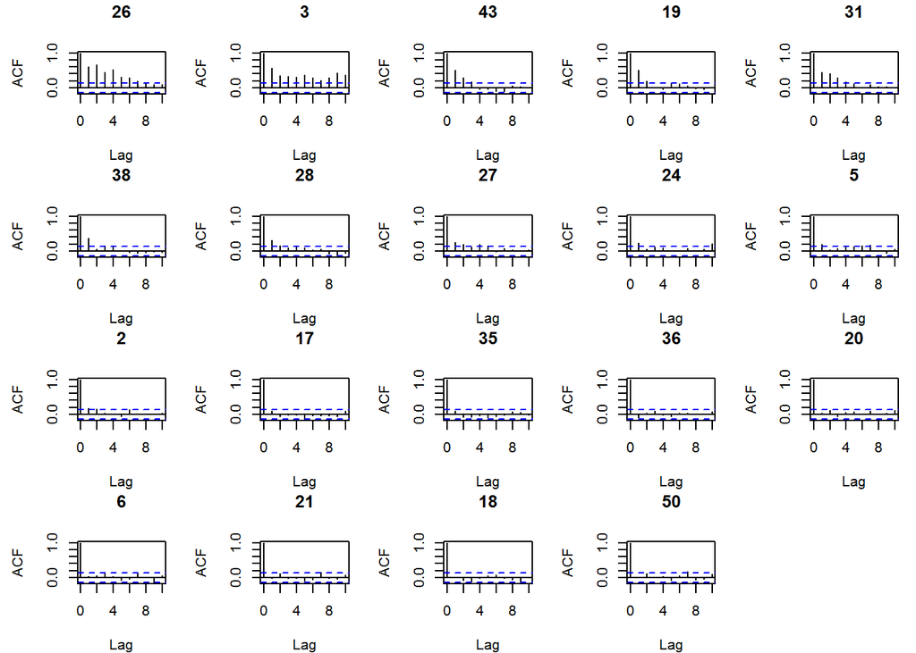

```r
for (x in acf.rank.3$ID){
  acf(ts.infmonthly[[x]],lag.max=10, plot=FALSE) %>% plot(main = x)

}

par(mfrow=c(1,1))
```

## Page 20

Paired sample t-tests

```r
paired.data <- long.data.40 %>% group_by(ID) %>% summarise(avg_choice = mean(Choice,na.rm=TRUE)) %>%
  inner_join(select(wide.data,ID,Type,Final.Choice),by="ID")

t.paired.test1 <- paired.data %>% filter(Type == 1)
t.paired.test2 <- paired.data %>% filter(Type == 2)
t.paired.test3 <- paired.data %>% filter(Type == 3)

t.test(t.paired.test1$avg_choice,t.paired.test1$Final.Choice,paired=TRUE)
```

```
##
##  Paired t-test
##
## data:  t.paired.test1$avg_choice and t.paired.test1$Final.Choice
## t = -1.0651, df = 17, p-value = 0.3017
## alternative hypothesis: true difference in means is not equal to 0
## 95 percent confidence interval:
##  -0.17181110  0.05653332
## sample estimates:
## mean of the differences
##             -0.05763889
```

```r
t.test(t.paired.test2$avg_choice,t.paired.test2$Final.Choice,paired=TRUE)
```

```
##
##  Paired t-test
##
## data:  t.paired.test2$avg_choice and t.paired.test2$Final.Choice
## t = -0.19389, df = 15, p-value = 0.8489
## alternative hypothesis: true difference in means is not equal to 0
## 95 percent confidence interval:
##  -0.07495619  0.06245619
## sample estimates:
## mean of the differences
##                -0.00625
```

```r
t.test(t.paired.test3$avg_choice,t.paired.test3$Final.Choice,paired=TRUE)
```

```
##
##  Paired t-test
##
## data:  t.paired.test3$avg_choice and t.paired.test3$Final.Choice
## t = -1.6606, df = 18, p-value = 0.1141
## alternative hypothesis: true difference in means is not equal to 0
## 95 percent confidence interval:
##  -0.20416128  0.02389812
## sample estimates:
## mean of the differences
##             -0.09013158
```

### Figure 4A-B

## Page 24

Comparing allocations over time (monthly vs. yearly conditions) (vs. inflated-monthly - B)

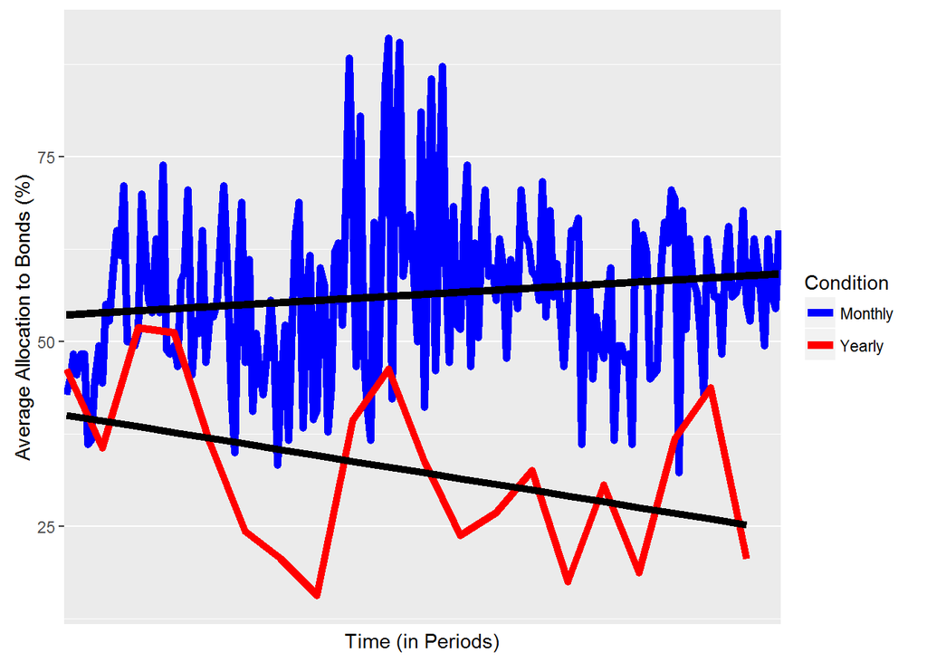

```r
monthly.data <- monthly %>% select(num_range("X",1:200)) %>% summarise_each(funs(mean)) %>%
  gather("Period","Avg_Choice",1:200) %>% mutate(Type = "Monthly")

yearly.data <- yearly %>% select(num_range("X",1:200)) %>% summarise_each(funs(mean)) %>%
  gather("Period","Avg_Choice",1:200) %>% filter(is.na(Avg_Choice)==FALSE) %>% mutate(Type = "Yearly")

inf.monthly.data <-  infmonthly %>% select(num_range("X",1:200)) %>% summarise_each(funs(mean)) %>%
  gather("Period","Avg_Choice",1:200) %>% mutate(Type = "Inflated Monthly")

graph.data <- bind_rows(monthly.data,yearly.data) %>% bind_rows(inf.monthly.data) %>%
  mutate(Avg_Choice=Avg_Choice*100)

graph.data %>% filter(Type %in% c("Monthly","Yearly")) %>%
  ggplot(aes(Period, Avg_Choice, group=Type)) +
  geom_line(size=2, aes(col=Type)) +
  scale_x_discrete(breaks=NULL) +
  scale_y_continuous(breaks=seq(0,100,25)) +
  scale_color_manual(values=c("Blue","Red"),name="Condition") +
  ylab("Average Allocation to Bonds (%)") + xlab("Time (in Periods)") +
  geom_smooth(method="lm",size=2,color="black",fill=NA)
```

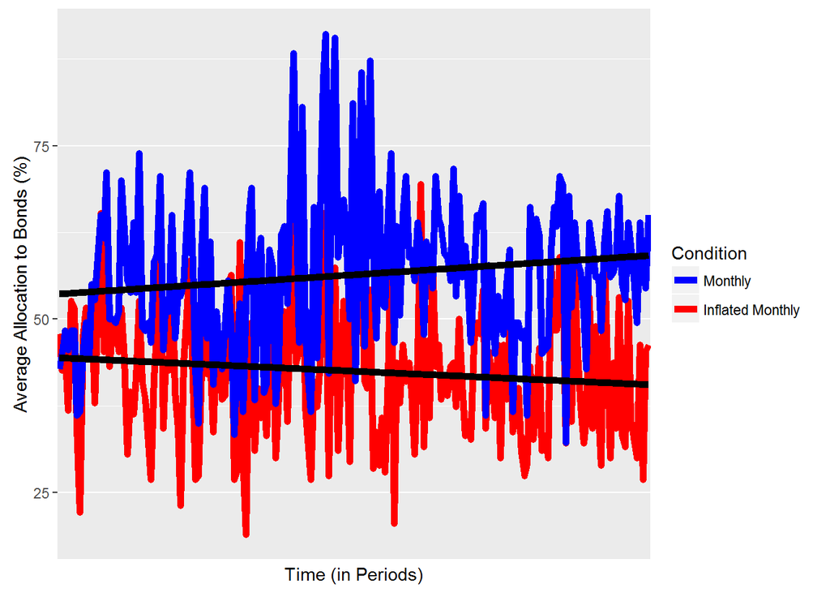

```r
graph.data %>% filter(Type %in% c("Monthly","Inflated Monthly")) %>%
  ggplot(aes(Period, Avg_Choice, group=Type)) +
  geom_line(size=2, aes(col=Type)) +
  scale_x_discrete(breaks=NULL) +
  scale_y_continuous(breaks=seq(0,100,25)) +
  scale_color_manual(values=c("Red","Blue"), name="Condition",breaks=c("Monthly","Inflated Monthly")) +
  ylab("Average Allocation to Bonds (%)") + xlab("Time (in Periods)") +
  geom_smooth(method="lm",size=2,color="black",fill=NA)
```

### Table 3

## Page 25

Regressions predicting allocation to Bond Fund (%) from trial number

```r
### Function to get cluster-robust standard errors
### Source: http://www.ne.su.se/polopoly_fs/1.216115.1426234213!/menu/standard/file/clustering1.pdf
clx <- function(fm, dfcw, cluster){
  M <- length(unique(cluster))
  N <- length(cluster)
  dfc <- (M/(M-1))*((N-1)/(N-fm$rank))
  u <- apply(estfun(fm),2,
             function(x) tapply(x, cluster, sum))
  vcovCL <- dfc*sandwich(fm, meat=crossprod(u)/N)*dfcw
  + coeftest(fm, vcovCL) }

fix.lm1 <- lm(Choice~Period + factor(ID) - 1,monthly.data.lm)


cluster.lm1 <- lm(Choice~Period,monthly.data.lm)


fix.lm2 <- lm(Choice~Period + factor(ID) - 1,yearly.data.lm)


cluster.lm2 <- lm(Choice~Period,yearly.data.lm)

fix.lm3 <- lm(Choice~Period + factor(ID) - 1,infmonthly.data.lm)


cluster.lm3 <- lm(Choice~Period,infmonthly.data.lm)
```

Fixed-Effects (Monthly, Yearly, Inflated-Monthly)

```r
summary(fix.lm1)
```

```
##
## Call:
## lm(formula = Choice ~ Period + factor(ID) - 1, data = monthly.data.lm)
##
## Residuals:
##     Min      1Q  Median      3Q     Max
## -85.014 -17.422   1.741  14.371  73.967
##
## Coefficients:
##               Estimate Std. Error t value Pr(>|t|)
## Period        0.027850   0.007561   3.683 0.000234 ***
## factor(ID)1  26.101047   2.001928  13.038  < 2e-16 ***
## factor(ID)9  24.251047   2.001928  12.114  < 2e-16 ***
## factor(ID)11 71.701047   2.001928  35.816  < 2e-16 ***
## factor(ID)13 33.151047   2.001928  16.560  < 2e-16 ***
## factor(ID)14 66.601047   2.001928  33.268  < 2e-16 ***
## factor(ID)16 31.351047   2.001928  15.660  < 2e-16 ***
## factor(ID)22 64.751047   2.001928  32.344  < 2e-16 ***
## factor(ID)25 46.851047   2.001928  23.403  < 2e-16 ***
## factor(ID)30 43.301047   2.001928  21.630  < 2e-16 ***
## factor(ID)40 65.901047   2.001928  32.919  < 2e-16 ***
## factor(ID)41 84.151047   2.001928  42.035  < 2e-16 ***
## factor(ID)42 33.401047   2.001928  16.684  < 2e-16 ***
## factor(ID)44 66.051047   2.001928  32.994  < 2e-16 ***
## factor(ID)45 85.301047   2.001928  42.609  < 2e-16 ***
## factor(ID)47 39.501047   2.001928  19.732  < 2e-16 ***
## factor(ID)49 82.201047   2.001928  41.061  < 2e-16 ***
## factor(ID)52 54.751047   2.001928  27.349  < 2e-16 ***
## factor(ID)53 45.451047   2.001928  22.704  < 2e-16 ***
## ---
## Signif. codes:  0 '***' 0.001 '**' 0.01 '*' 0.05 '.' 0.1 ' ' 1
##
## Residual standard error: 26.19 on 3581 degrees of freedom
## Multiple R-squared:  0.8397, Adjusted R-squared:  0.8388
## F-statistic: 987.2 on 19 and 3581 DF,  p-value: < 2.2e-16
```

```r
summary(fix.lm2)
```

```
##
## Call:
## lm(formula = Choice ~ Period + factor(ID) - 1, data = yearly.data.lm)
##
## Residuals:
##     Min      1Q  Median      3Q     Max
## -32.827 -11.273  -2.609  10.289  67.417
##
## Coefficients:
##              Estimate Std. Error t value Pr(>|t|)
## Period        -0.7820     0.1633  -4.789 2.63e-06 ***
## factor(ID)4   42.7105     4.1380  10.321  < 2e-16 ***
## factor(ID)7   58.7105     4.1380  14.188  < 2e-16 ***
## factor(ID)8   49.7105     4.1380  12.013  < 2e-16 ***
## factor(ID)10  35.7105     4.1380   8.630 3.53e-16 ***
## factor(ID)12  42.2105     4.1380  10.201  < 2e-16 ***
## factor(ID)15  56.2105     4.1380  13.584  < 2e-16 ***
## factor(ID)23  36.2105     4.1380   8.751  < 2e-16 ***
## factor(ID)29  19.7105     4.1380   4.763 2.96e-06 ***
## factor(ID)32  40.7105     4.1380   9.838  < 2e-16 ***
## factor(ID)33  36.2105     4.1380   8.751  < 2e-16 ***
## factor(ID)34  45.2105     4.1380  10.926  < 2e-16 ***
## factor(ID)37  37.7105     4.1380   9.113  < 2e-16 ***
## factor(ID)39  42.2105     4.1380  10.201  < 2e-16 ***
## factor(ID)46  39.2105     4.1380   9.476  < 2e-16 ***
## factor(ID)48  25.7105     4.1380   6.213 1.71e-09 ***
## factor(ID)51  45.2105     4.1380  10.926  < 2e-16 ***
## ---
## Signif. codes:  0 '***' 0.001 '**' 0.01 '*' 0.05 '.' 0.1 ' ' 1
##
## Residual standard error: 16.84 on 303 degrees of freedom
## Multiple R-squared:  0.8139, Adjusted R-squared:  0.8034
## F-statistic: 77.94 on 17 and 303 DF,  p-value: < 2.2e-16
```

```r
summary(fix.lm3)
```

```
##
## Call:
## lm(formula = Choice ~ Period + factor(ID) - 1, data = infmonthly.data.lm)
##
## Residuals:
##     Min      1Q  Median      3Q     Max
## -51.362 -14.356   0.054  10.087  75.368
##
## Coefficients:
##               Estimate Std. Error t value Pr(>|t|)
## Period       -0.019531   0.006897  -2.832  0.00465 **
## factor(ID)2  26.012893   1.868881  13.919  < 2e-16 ***
## factor(ID)3  49.962893   1.868881  26.734  < 2e-16 ***
## factor(ID)5  51.412893   1.868881  27.510  < 2e-16 ***
## factor(ID)6  46.112893   1.868881  24.674  < 2e-16 ***
## factor(ID)17 51.112893   1.868881  27.349  < 2e-16 ***
## factor(ID)18 50.662893   1.868881  27.109  < 2e-16 ***
## factor(ID)19 50.712893   1.868881  27.135  < 2e-16 ***
## factor(ID)20 49.012893   1.868881  26.226  < 2e-16 ***
## factor(ID)21 48.262893   1.868881  25.824  < 2e-16 ***
## factor(ID)24 42.312893   1.868881  22.641  < 2e-16 ***
## factor(ID)26 27.112893   1.868881  14.508  < 2e-16 ***
## factor(ID)27 45.112893   1.868881  24.139  < 2e-16 ***
## factor(ID)28 51.762893   1.868881  27.697  < 2e-16 ***
## factor(ID)31 46.712893   1.868881  24.995  < 2e-16 ***
## factor(ID)35 52.162893   1.868881  27.911  < 2e-16 ***
## factor(ID)36 35.362893   1.868881  18.922  < 2e-16 ***
## factor(ID)38 28.912893   1.868881  15.471  < 2e-16 ***
## factor(ID)43 45.462893   1.868881  24.326  < 2e-16 ***
## factor(ID)50 46.512893   1.868881  24.888  < 2e-16 ***
## ---
## Signif. codes:  0 '***' 0.001 '**' 0.01 '*' 0.05 '.' 0.1 ' ' 1
##
## Residual standard error: 24.55 on 3780 degrees of freedom
## Multiple R-squared:  0.758,  Adjusted R-squared:  0.7567
## F-statistic:   592 on 20 and 3780 DF,  p-value: < 2.2e-16
```

Cluster-Robust SE’s (Monthly, Yearly, Inflated-Monthly)

```r
clx(cluster.lm1,1,monthly.data.lm$ID)
```

```
##
## t test of coefficients:
##
##              Estimate Std. Error t value Pr(>|t|)
## (Intercept) 53.598269   3.464521 15.4706   <2e-16 ***
## Period       0.027850   0.031765  0.8768   0.3807
## ---
## Signif. codes:  0 '***' 0.001 '**' 0.01 '*' 0.05 '.' 0.1 ' ' 1
```

```r
clx(cluster.lm2,1,yearly.data.lm$ID)
```

```
##
## t test of coefficients:
##
##             Estimate Std. Error t value  Pr(>|t|)
## (Intercept) 40.83553    2.38508 17.1212 < 2.2e-16 ***
## Period      -0.78195    0.15975 -4.8949 1.567e-06 ***
## ---
## Signif. codes:  0 '***' 0.001 '**' 0.01 '*' 0.05 '.' 0.1 ' ' 1
```

```r
clx(cluster.lm3,1,infmonthly.data.lm$ID)
```

```
##
## t test of coefficients:
##
##              Estimate Std. Error t value Pr(>|t|)
## (Intercept) 44.457630   1.986901 22.3754   <2e-16 ***
## Period      -0.019531   0.016085 -1.2143   0.2247
## ---
## Signif. codes:  0 '***' 0.001 '**' 0.01 '*' 0.05 '.' 0.1 ' ' 1
```

Fixed-Effects and Cluster-Robust SE’s (Monthly, Yearly, Inflated-Monthly)

```r
clx(fix.lm1,1,monthly.data.lm$ID)
```

```
##
## t test of coefficients:
##
##              Estimate Std. Error t value  Pr(>|t|)
## Period        0.02785    0.03184  0.8747    0.3818
## factor(ID)1  26.10105    3.19996  8.1567 4.715e-16 ***
## factor(ID)9  24.25105    3.19996  7.5786 4.423e-14 ***
## factor(ID)11 71.70105    3.19996 22.4069 < 2.2e-16 ***
## factor(ID)13 33.15105    3.19996 10.3598 < 2.2e-16 ***
## factor(ID)14 66.60105    3.19996 20.8131 < 2.2e-16 ***
## factor(ID)16 31.35105    3.19996  9.7973 < 2.2e-16 ***
## factor(ID)22 64.75105    3.19996 20.2350 < 2.2e-16 ***
## factor(ID)25 46.85105    3.19996 14.6412 < 2.2e-16 ***
## factor(ID)30 43.30105    3.19996 13.5318 < 2.2e-16 ***
## factor(ID)40 65.90105    3.19996 20.5944 < 2.2e-16 ***
## factor(ID)41 84.15105    3.19996 26.2976 < 2.2e-16 ***
## factor(ID)42 33.40105    3.19996 10.4380 < 2.2e-16 ***
## factor(ID)44 66.05105    3.19996 20.6412 < 2.2e-16 ***
## factor(ID)45 85.30105    3.19996 26.6569 < 2.2e-16 ***
## factor(ID)47 39.50105    3.19996 12.3442 < 2.2e-16 ***
## factor(ID)49 82.20105    3.19996 25.6882 < 2.2e-16 ***
## factor(ID)52 54.75105    3.19996 17.1099 < 2.2e-16 ***
## factor(ID)53 45.45105    3.19996 14.2036 < 2.2e-16 ***
## ---
## Signif. codes:  0 '***' 0.001 '**' 0.01 '*' 0.05 '.' 0.1 ' ' 1
```

```r
clx(fix.lm2,1,yearly.data.lm$ID)
```

```
##
## t test of coefficients:
##
##              Estimate Std. Error t value  Pr(>|t|)
## Period       -0.78195    0.16365 -4.7781 2.763e-06 ***
## factor(ID)4  42.71053    1.71837 24.8552 < 2.2e-16 ***
## factor(ID)7  58.71053    1.71837 34.1663 < 2.2e-16 ***
## factor(ID)8  49.71053    1.71837 28.9288 < 2.2e-16 ***
## factor(ID)10 35.71053    1.71837 20.7816 < 2.2e-16 ***
## factor(ID)12 42.21053    1.71837 24.5642 < 2.2e-16 ***
## factor(ID)15 56.21053    1.71837 32.7114 < 2.2e-16 ***
## factor(ID)23 36.21053    1.71837 21.0725 < 2.2e-16 ***
## factor(ID)29 19.71053    1.71837 11.4704 < 2.2e-16 ***
## factor(ID)32 40.71053    1.71837 23.6913 < 2.2e-16 ***
## factor(ID)33 36.21053    1.71837 21.0725 < 2.2e-16 ***
## factor(ID)34 45.21053    1.71837 26.3100 < 2.2e-16 ***
## factor(ID)37 37.71053    1.71837 21.9455 < 2.2e-16 ***
## factor(ID)39 42.21053    1.71837 24.5642 < 2.2e-16 ***
## factor(ID)46 39.21053    1.71837 22.8184 < 2.2e-16 ***
## factor(ID)48 25.71053    1.71837 14.9621 < 2.2e-16 ***
## factor(ID)51 45.21053    1.71837 26.3100 < 2.2e-16 ***
## ---
## Signif. codes:  0 '***' 0.001 '**' 0.01 '*' 0.05 '.' 0.1 ' ' 1
```

```r
clx(fix.lm3,1,infmonthly.data.lm$ID)
```

```
##
## t test of coefficients:
##
##               Estimate Std. Error t value Pr(>|t|)
## Period       -0.019531   0.016123 -1.2114   0.2258
## factor(ID)2  26.012893   1.620355 16.0538   <2e-16 ***
## factor(ID)3  49.962893   1.620355 30.8345   <2e-16 ***
## factor(ID)5  51.412893   1.620355 31.7294   <2e-16 ***
## factor(ID)6  46.112893   1.620355 28.4585   <2e-16 ***
## factor(ID)17 51.112893   1.620355 31.5442   <2e-16 ***
## factor(ID)18 50.662893   1.620355 31.2665   <2e-16 ***
## factor(ID)19 50.712893   1.620355 31.2974   <2e-16 ***
## factor(ID)20 49.012893   1.620355 30.2482   <2e-16 ***
## factor(ID)21 48.262893   1.620355 29.7854   <2e-16 ***
## factor(ID)24 42.312893   1.620355 26.1133   <2e-16 ***
## factor(ID)26 27.112893   1.620355 16.7327   <2e-16 ***
## factor(ID)27 45.112893   1.620355 27.8414   <2e-16 ***
## factor(ID)28 51.762893   1.620355 31.9454   <2e-16 ***
## factor(ID)31 46.712893   1.620355 28.8288   <2e-16 ***
## factor(ID)35 52.162893   1.620355 32.1923   <2e-16 ***
## factor(ID)36 35.362893   1.620355 21.8242   <2e-16 ***
## factor(ID)38 28.912893   1.620355 17.8435   <2e-16 ***
## factor(ID)43 45.462893   1.620355 28.0574   <2e-16 ***
## factor(ID)50 46.512893   1.620355 28.7054   <2e-16 ***
## ---
## Signif. codes:  0 '***' 0.001 '**' 0.01 '*' 0.05 '.' 0.1 ' ' 1
```

### Table 4.

## Page 26

Regressions of final allocation to Bond Fund (%) on various measurements of finance knowledge and recollection of stock value loss.

```r
sum(wide.data$Q6 != "DK")
```

```
## [1] 31
```

```r
sum(wide.data$Q7 != "DK")
```

```
## [1] 47
```

```r
survey.lm1 <- wide.data %>% select(Final.Choice,Q6,Q7) %>%
  mutate(tech.dummy=ifelse(Q6 == "DK",0,1),fin.dummy=ifelse(Q7 == "DK",0,1),Final.Choice=Final.Choice*100)
survey.lm2 <- survey.lm1 %>% filter(Q6 != "DK") %>% mutate(Q6=as.numeric(as.character(Q6))*100)
survey.lm3 <- survey.lm1 %>% filter(Q7 != "DK") %>% mutate(Q7=as.numeric(as.character(Q7))*100)

summary(lm(Final.Choice~tech.dummy + fin.dummy,survey.lm1))
```

```
##
## Call:
## lm(formula = Final.Choice ~ tech.dummy + fin.dummy, data = survey.lm1)
##
## Residuals:
##     Min      1Q  Median      3Q     Max
## -49.032 -19.375  -6.667  20.968  50.968
##
## Coefficients:
##             Estimate Std. Error t value Pr(>|t|)
## (Intercept)  46.6667    12.8450   3.633  0.00066 ***
## tech.dummy   -0.3427     9.6854  -0.035  0.97191
## fin.dummy     2.7083    15.0621   0.180  0.85803
## ---
## Signif. codes:  0 '***' 0.001 '**' 0.01 '*' 0.05 '.' 0.1 ' ' 1
##
## Residual standard error: 31.46 on 50 degrees of freedom
## Multiple R-squared:  0.0006869,  Adjusted R-squared:  -0.03929
## F-statistic: 0.01718 on 2 and 50 DF,  p-value: 0.983
```

```r
summary(lm(Final.Choice~Q6,survey.lm2))
```

```
##
## Call:
## lm(formula = Final.Choice ~ Q6, data = survey.lm2)
##
## Residuals:
##     Min      1Q  Median      3Q     Max
## -51.071 -31.784   3.882  26.096  55.120
##
## Coefficients:
##             Estimate Std. Error t value Pr(>|t|)
## (Intercept)  54.7859     8.7125   6.288 7.25e-07 ***
## Q6           -0.1238     0.1301  -0.951    0.349
## ---
## Signif. codes:  0 '***' 0.001 '**' 0.01 '*' 0.05 '.' 0.1 ' ' 1
##
## Residual standard error: 34.92 on 29 degrees of freedom
## Multiple R-squared:  0.03027,    Adjusted R-squared:  -0.003167
## F-statistic: 0.9053 on 1 and 29 DF,  p-value: 0.3492
```

```r
summary(lm(Final.Choice~Q7,survey.lm3))
```

```
##
## Call:
## lm(formula = Final.Choice ~ Q7, data = survey.lm3)
##
## Residuals:
##     Min      1Q  Median      3Q     Max
## -52.033 -18.820  -6.887  22.576  52.491
##
## Coefficients:
##             Estimate Std. Error t value Pr(>|t|)
## (Intercept) 46.37773    6.03212   7.688 9.83e-10 ***
## Q7           0.05656    0.07755   0.729     0.47
## ---
## Signif. codes:  0 '***' 0.001 '**' 0.01 '*' 0.05 '.' 0.1 ' ' 1
##
## Residual standard error: 32.12 on 45 degrees of freedom
## Multiple R-squared:  0.01168,    Adjusted R-squared:  -0.01028
## F-statistic: 0.5318 on 1 and 45 DF,  p-value: 0.4696
```